# Praca domowa 8

Tomasz Siudalski

17 01 2022

## Data Overview

|  | Variable class | Unique values | Missing observations |
| --- | --- | --- | --- |
| Overall.rank | integer | 156 | 0 |
| Country.or.region | character | 156 | 0 |
| Score | numeric | 156 | 0 |
| GDP.per.capita | numeric | 156 | 0 |
| Social.support | numeric | 156 | 0 |
| Healthy.life.expectancy | numeric | 156 | 0 |
| Freedom.to.make.life.choices | numeric | 156 | 0 |
| Generosity | numeric | 156 | 0 |
| Perceptions.of.corruption | numeric | 156 | 0 |

## Variable List

Część ta zawiera krótki opis każdej zmiennej i ich rozkłady.

### Overall.rank

Zmienna opisująca miejsce danego państwa w rankingu szczęśliwości.

### Country.or.region

Zmienna zawierająca nazwy państw lub regionów.

### Score

Zmienna opisująca wynik danego państwa.

| Min. | 2.853000 |
| --- | --- |
| 1st Qu. | 4.544500 |
| Median | 5.379500 |
| Mean | 5.407096 |
| 3rd Qu. | 6.184500 |
| Max. | 7.769000 |

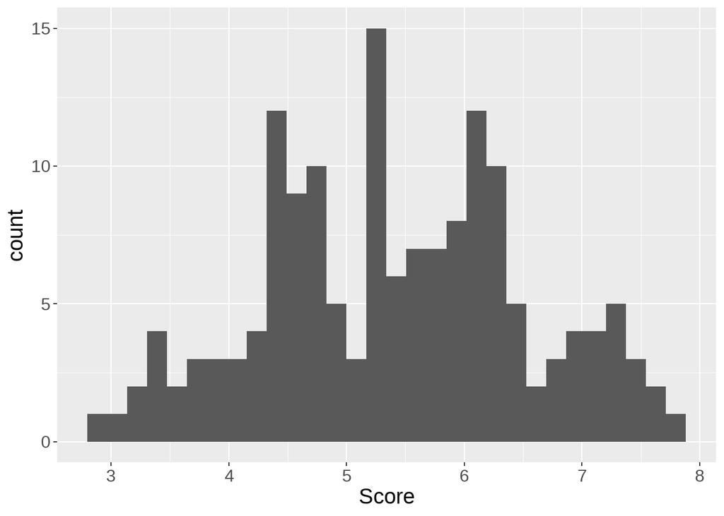

### GDP.per.capita

Zmienna opisująca produkt krajowy brutto na obywatela.

| Min. | 0.0000000 |
| --- | --- |
| 1st Qu. | 0.6027500 |
| Median | 0.9600000 |
| Mean | 0.9051474 |
| 3rd Qu. | 1.2325000 |
| Max. | 1.6840000 |

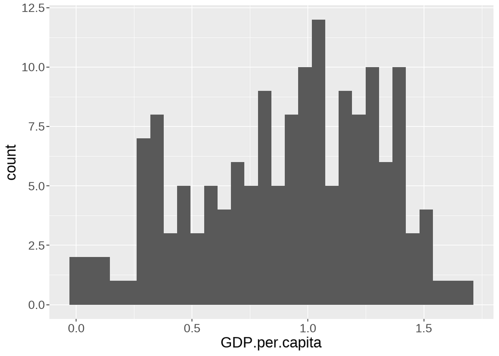

### Social.support

Zmienna odpowiadająca wsparciu społecznemu.

| Min. | 0.000000 |
| --- | --- |
| 1st Qu. | 1.055750 |
| Median | 1.271500 |
| Mean | 1.208814 |
| 3rd Qu. | 1.452500 |
| Max. | 1.624000 |

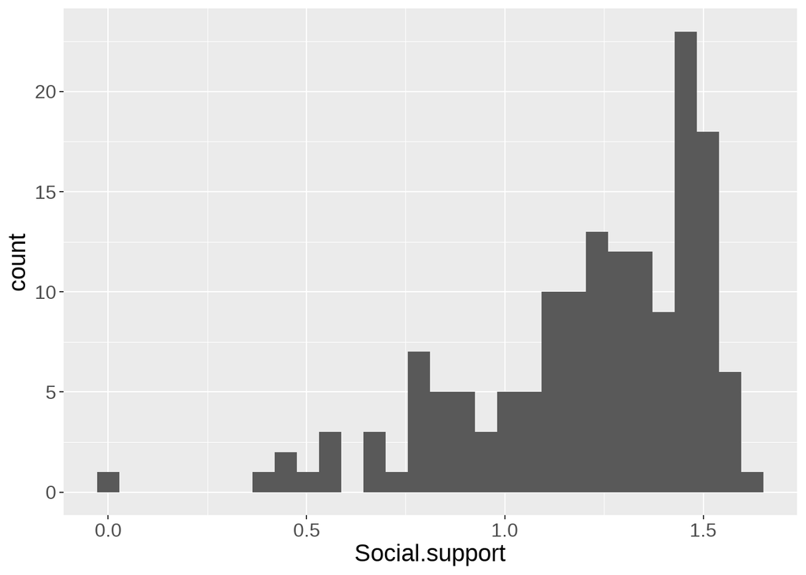

### Healthy.life.expectancy

Zmienna opisująca prawdopodobieństwo zdrowego życia w danym państwie.

| Min. | 0.0000000 |
| --- | --- |
| 1st Qu. | 0.5477500 |
| Median | 0.7890000 |
| Mean | 0.7252436 |
| 3rd Qu. | 0.8817500 |
| Max. | 1.1410000 |

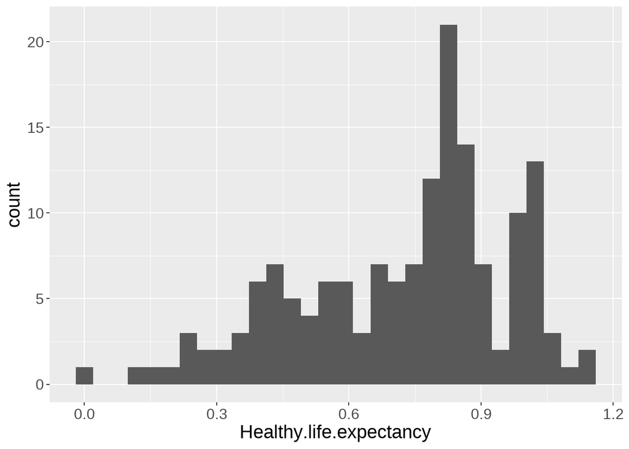

### Freedom.to.make.life.choices

Zmienna symbolizująca poczucie wolności obywateli w podejmowaniu życiowych decyzji.

| Min. | 0.0000000 |
| --- | --- |
| 1st Qu. | 0.3080000 |
| Median | 0.4170000 |
| Mean | 0.3925705 |
| 3rd Qu. | 0.5072500 |
| Max. | 0.6310000 |

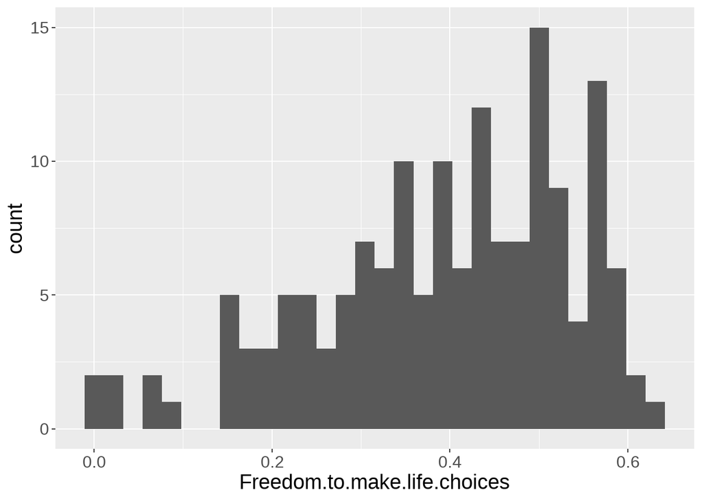

### Generosity

Zmienna opisująca hojność obywateli.

| Min. | 0.0000000 |
| --- | --- |
| 1st Qu. | 0.1087500 |
| Median | 0.1775000 |
| Mean | 0.1848462 |
| 3rd Qu. | 0.2482500 |
| Max. | 0.5660000 |

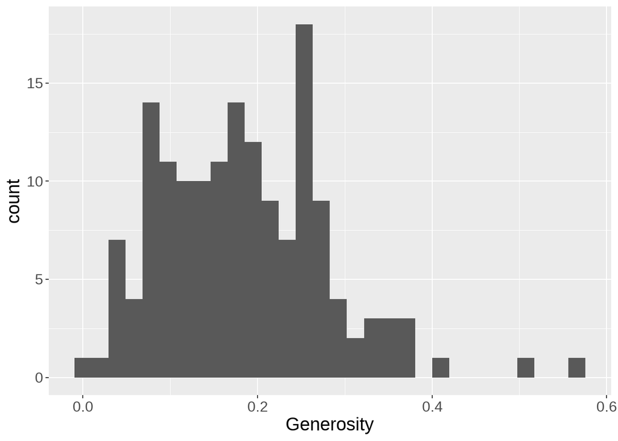

### Perceptions.of.corruption

Zmienna opisująca postrzeganie korupcji.

| Min. | 0.0000000 |
| --- | --- |
| 1st Qu. | 0.0470000 |
| Median | 0.0855000 |
| Mean | 0.1106026 |
| 3rd Qu. | 0.1412500 |
| Max. | 0.4530000 |

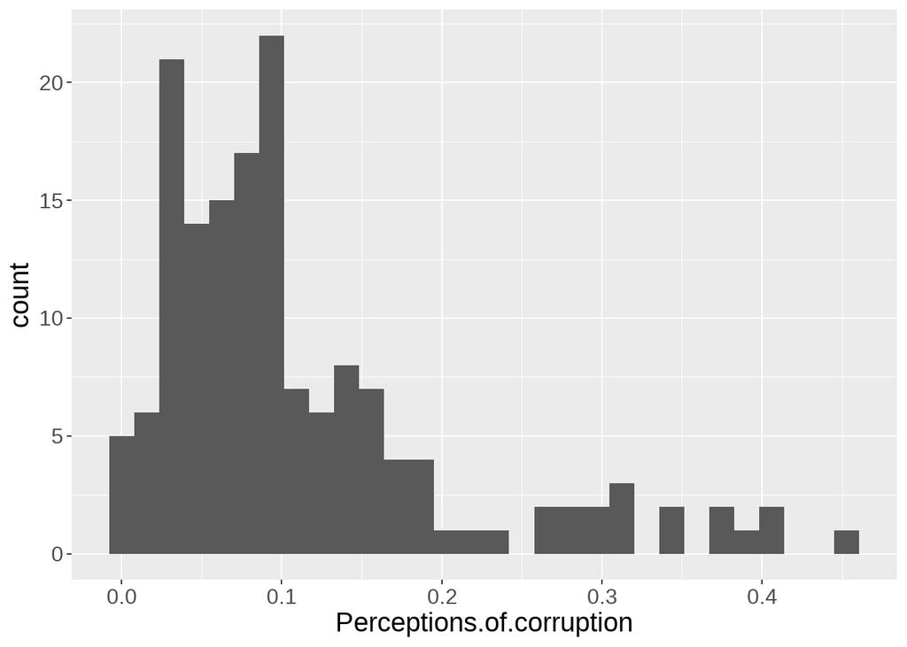

## Correlations

Teraz zajmę się badaniem zależności pomiędzy zmiennymi.

### Table of correlation

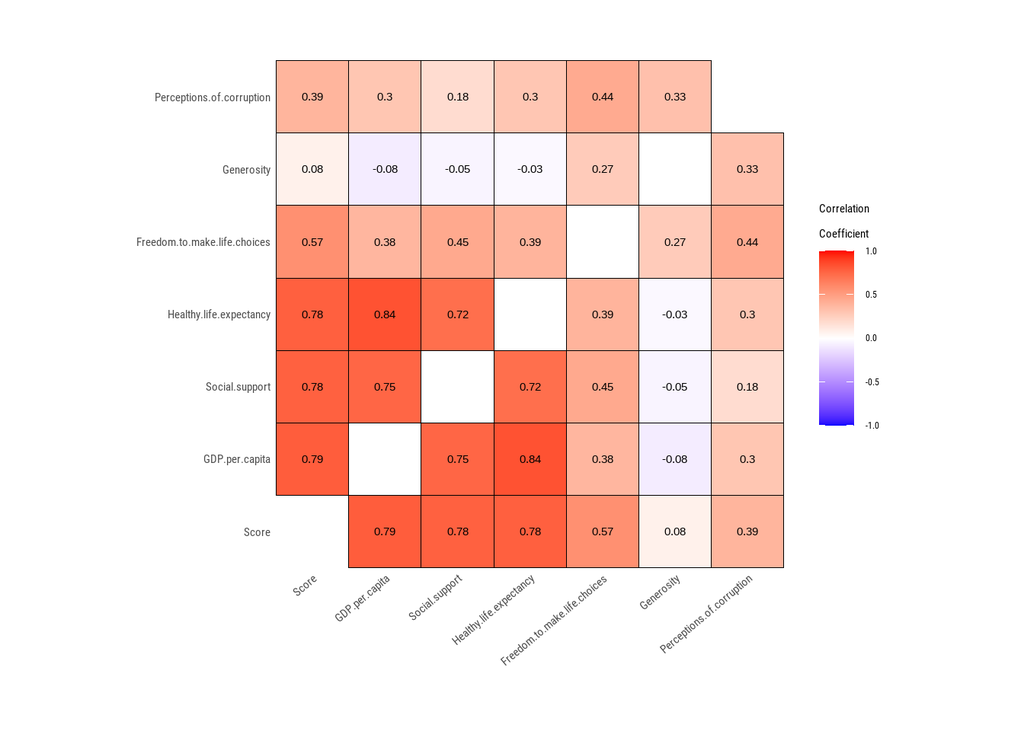

Możemy zaobserwować dość silne zależności między dowolnymi dwoma ze zmiennych Score, GDP.per.capita, Healthy.life.expectancy i Social.Support. Prawdopodobnie w większości przypadków im bogatsze jest państwo (z wysokim produktem brutto na obywatela) tym lepiej ma rozwinięte programy społeczne i posiada nowocześniejszą służbę zdrowia, która przekłada się pozytywnie na długość życia obywateli. Z tego powodu wszystkie trzy z tych zmiennych wpływają mocno na wynik. W dalszej części dodatkowo zbadam te zależności.

### GDP.per.capita & Healthy.life.expectancy

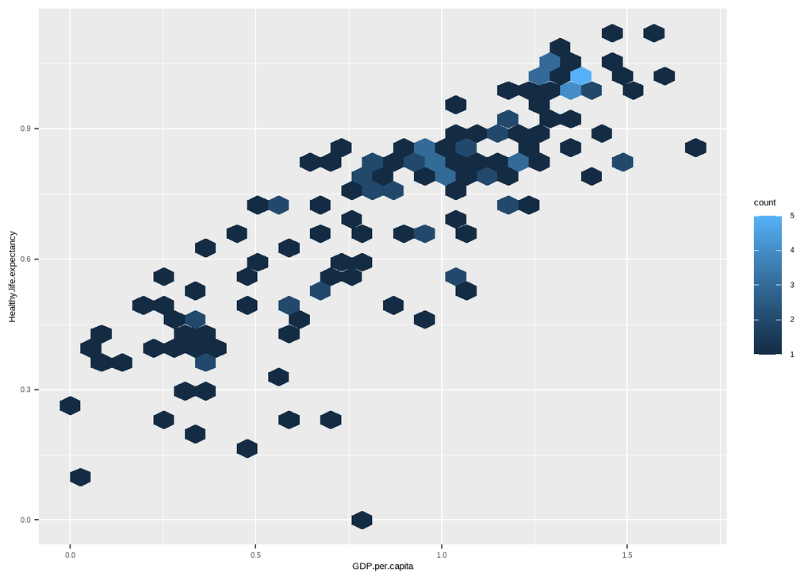

Jak widać na wykresie, w większości przypadków prawdobodobieństwo zdrowego życia dla obywateli rośnie wraz ze wzrostem zamożności państwa. Odstępstwa mogą być między innymi spowodowane położeniem geograficznym państwa i prawdopodobieństwem wystąpienia katastrof naturalnych.

### GDP.per.capita & Social.support

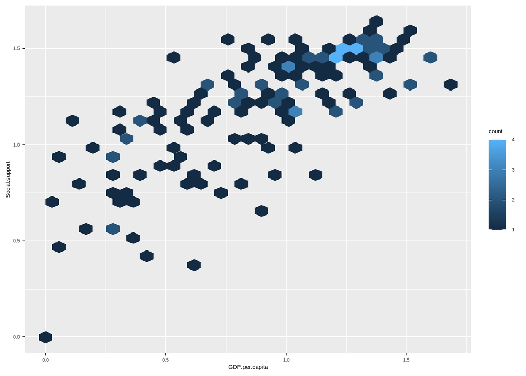

Jak pokazuje wykres, w wiekszości przyapdków im zamożniejsze jest państwo tym lepsze jest wsparcie społeczne. Zależność ta tutaj również jest tym większa im większe wartości przyjmują zmienne. Może być to spowodowane tym, że w bogatych państwach pieniędzy starcza na wszystko, a biedniejsze mają różne priorytety w wydawaniu budżetu.

### Continent

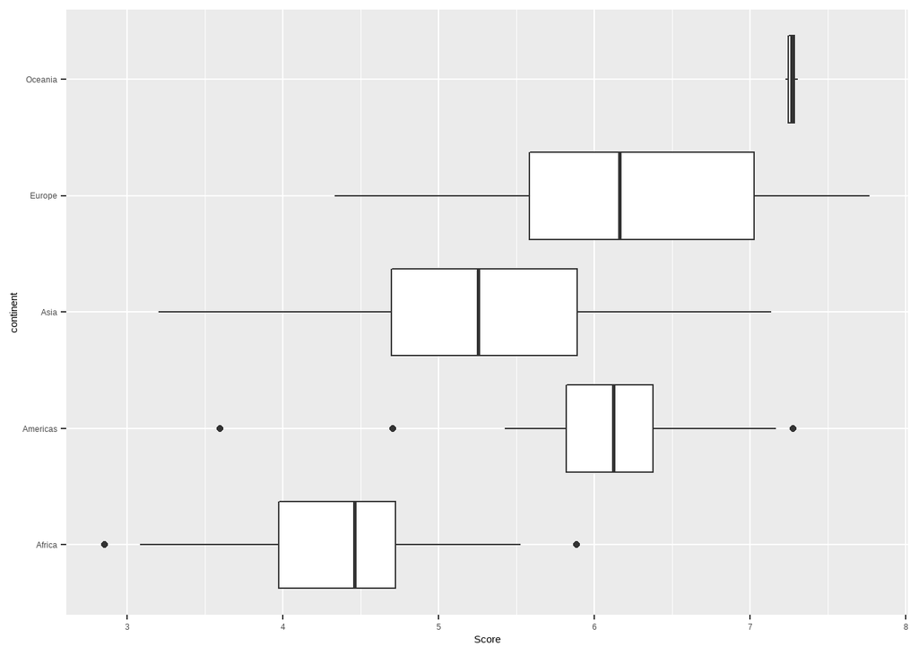

Jak widać na wykresie, większość z państw osiągających wysokie wyniki to państwa europejskie, kraje afrykańskie za to osiągają w większości najgorsze wyniki.